# Gender and Nationality in the Tate Gallery Collection

Laura Mathilde Yong Li Nielsen

2021-12-09

# Tate Gallery

Tate Gallery is a British Museum institution consisting of five museums or galleries in the United Kingdom. This code explores gender and nationality in terms of artists and pieces of artwork represented in the Tate archive/collection. The project seeks to dissect continuity and change in the collection and foresees change in terms of female artists representation the past centuries.

# Install packages

```r
library(tidyverse)
```

```r
library(dplyr)
library(ggplot2)
library(gganimate)
```

## Read files

```r
artist <- read_csv("artist_clean.csv")
artwork <- read_csv("artwork_clean.csv")
```

# Working with artist_clean.csv

## Female artists

```r
gender <- artist$gender

birth <- artist$birth
```

### Counting gender

```r
artist %>%
  count(gender)
```

```
## # A tibble: 3 × 2
##   gender     n
##   <chr>  <int>
## 1 Female   521
## 2 Male    2895
## 3 <NA>     116
```

### Using regular expressions (grepl) and filtering to create a new data frame (df) only with women

```r
femaleartist <- artist %>%
  filter(grepl("Female", gender))

femaleartist
```

```
## # A tibble: 521 × 5
##       id name                   gender birth nationality
##    <dbl> <chr>                  <chr>  <dbl> <chr>
##  1 10093 Abakanowicz, Magdalena Female  1930 Poland
##  2  2756 Abbott, Berenice       Female  1898 United States
##  3  9550 Abts, Tomma            Female  1967 Germany
##  4  2608 Adshead, Mary          Female  1904 United Kingdom
##  5   633 Agar, Eileen           Female  1899 Argentina
##  6  3098 Ahtila, Eija-Liisa     Female  1959 Suomi
##  7  7794 Al-Ani, Jananne        Female  1966 Iraq
##  8  3067 Albers, Anni           Female  1899 Germany
##  9   641 Allan, Julian Phelps   Female  1892 United Kingdom
## 10   642 Alley, Anthea          Female  1927 Malaysia
## # … with 511 more rows
```

### Development in female artists

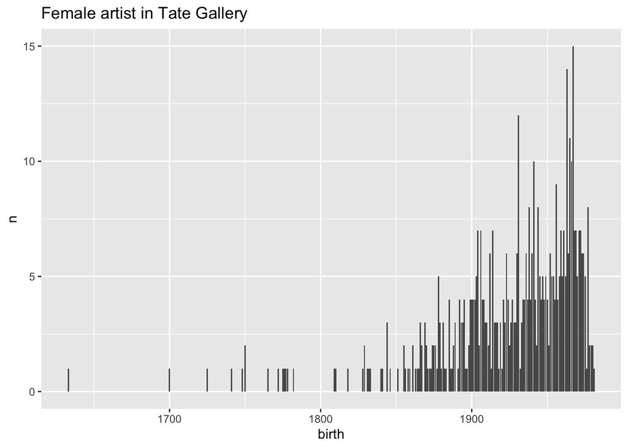

```r
femaleartist%>%
  count(birth, gender, nationality) %>%
  ggplot(mapping = aes(x=birth, y=n))+
  geom_col()+
  labs(title= "Female artist in Tate Gallery")
```

```r
femaleartist
```

```
## # A tibble: 521 × 5
##       id name                   gender birth nationality
##    <dbl> <chr>                  <chr>  <dbl> <chr>
##  1 10093 Abakanowicz, Magdalena Female  1930 Poland
##  2  2756 Abbott, Berenice       Female  1898 United States
##  3  9550 Abts, Tomma            Female  1967 Germany
##  4  2608 Adshead, Mary          Female  1904 United Kingdom
##  5   633 Agar, Eileen           Female  1899 Argentina
##  6  3098 Ahtila, Eija-Liisa     Female  1959 Suomi
##  7  7794 Al-Ani, Jananne        Female  1966 Iraq
##  8  3067 Albers, Anni           Female  1899 Germany
##  9   641 Allan, Julian Phelps   Female  1892 United Kingdom
## 10   642 Alley, Anthea          Female  1927 Malaysia
## # … with 511 more rows
```

This plot shows the birth years of every female artist in the artist_clean.csv data set on the x-axis and the number of female artists born on the y-axis.

## Creating decades to improve and compare the prior plot

```r
artist[c("birth")]
```

```
## # A tibble: 3,532 × 1
##    birth
##    <dbl>
##  1  1930
##  2  1852
##  3  1898
##  4  1760
##  5  1935
##  6  1964
##  7  1967
##  8  1940
##  9  1947
## 10  1938
## # … with 3,522 more rows
```

```r
decade <- artist[c("birth", "gender")]

# Changing interval in counting male, female and NA in gender in a century and copying them to my new df "CenturyGender".
filter(artist,birth %in% 1500:1599) %>%
  count(gender)
```

```
## # A tibble: 2 × 2
##   gender     n
##   <chr>  <int>
## 1 Male      17
## 2 <NA>       3
```

```r
CenturyGender <- data.frame(Century=c(16., 17., 18., 19., 20.),
                            Male=c(17,70,377,904,1509),
                            Female=c(0,1,13,94,404),
                            Total=c(20,70,396,1025,1959),
                            na=c(3,6,6,27,46))
CenturyGender
```

```
##   Century Male Female Total na
## 1      16   17      0    20  3
## 2      17   70      1    70  6
## 3      18  377     13   396  6
## 4      19  904     94  1025 27
## 5      20 1509    404  1959 46
```

### A plot with “Number of Female artists in the Tate Gallery Collection, 1500-1999”

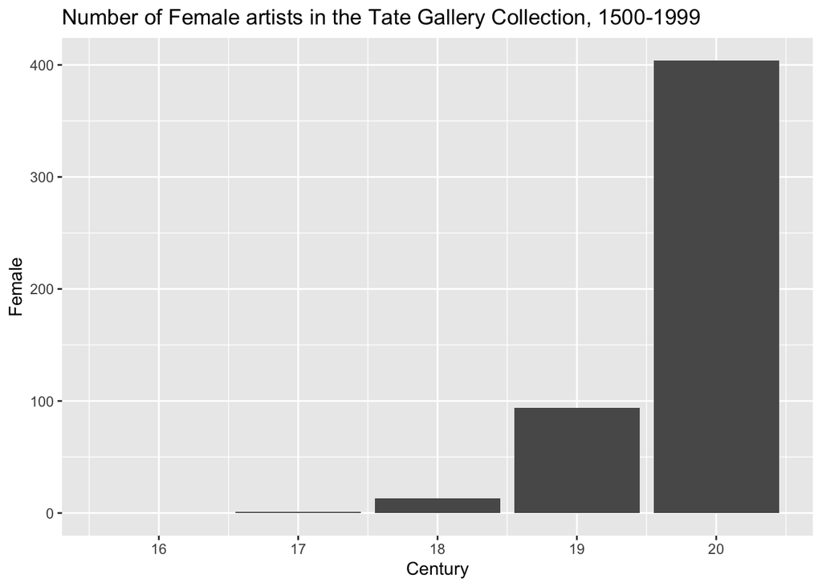

```r
CenturyGenderColFemale <- ggplot(CenturyGender, aes(Century, Female))+
  geom_col()+
  labs(title = "Number of Female artists in the Tate Gallery Collection, 1500-1999")

CenturyGenderColFemale
```

### A plot with “Number of Male artists in the Tate Gallery Collection, 1500-1999”

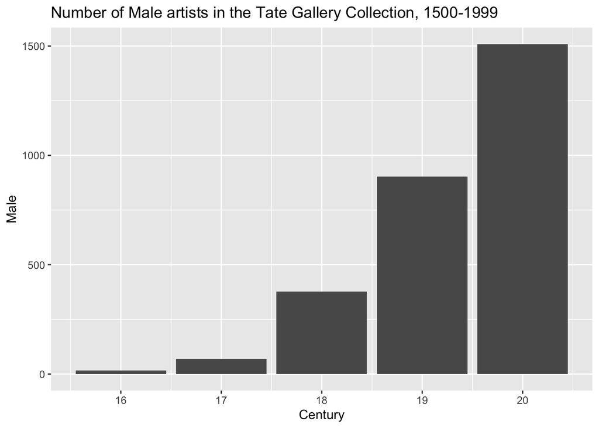

```r
CenturyGenderColMale <- ggplot(CenturyGender, aes(Century, Male))+
  geom_col()+
  labs(title = "Number of Male artists in the Tate Gallery Collection, 1500-1999")
CenturyGenderColMale
```

These two visualizations show the number of male/female artists in the Tate Gallery Collection from 1500-1999.

## Working with nationality: Indian born artists

```r
nationality <- read_csv("~/Desktop/Tate/artist_clean.csv")
```

### Filtering out Indian born artists

```r
Indianartist <- nationality%>%
  filter(grepl("India", nationality))

Indianartist
```

```
## # A tibble: 23 × 5
##       id name                         gender birth nationality
##    <dbl> <chr>                        <chr>  <dbl> <chr>
##  1   786 Bosman, Richard              Male    1944 India
##  2   886 Chandra, Avinash             Male    1931 India
##  3   903 Chowne, Gerard               Male    1875 India
##  4   931 Colquhoun, Ithell            Female  1906 India
##  5   978 David, Allen                 Male    1926 India
##  6  1136 Fyzee-Rahamin, Samuel        Male    1880 India
##  7 12171 Gupta, Subodh                Male    1964 India
##  8  1250 Hartrick, Archibald Standish Male    1864 India
##  9 17194 Hashmi, Zarina               Female  1937 India
## 10   278 Houghton, Arthur Boyd        Male    1836 India
## # … with 13 more rows
```

### Plotting with Indian born artists and gender

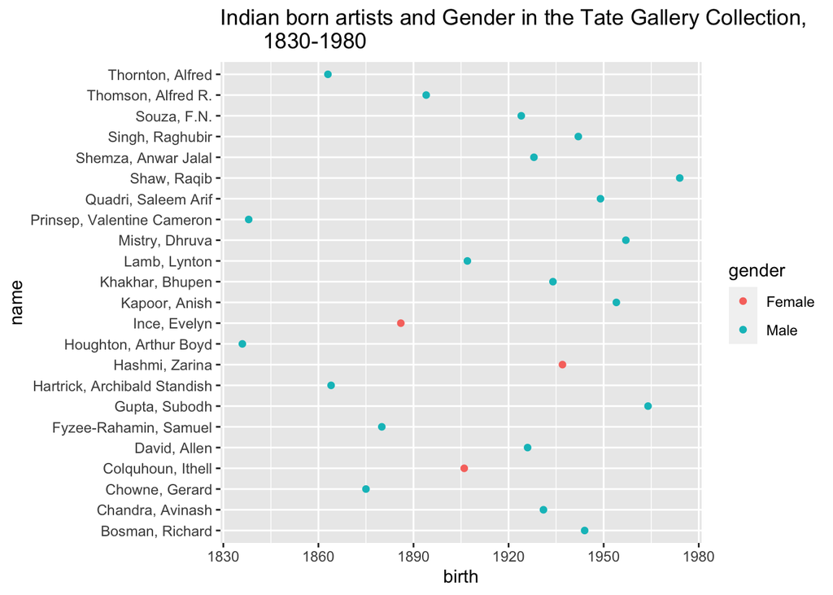

```r
Indianartist%>%
  ggplot(mapping = aes(x=birth, y=name, colour= gender))+
  geom_point()+
  labs(title = "Indian born artists and Gender in the Tate Gallery Collection,
       1830-1980")
```

This plot shows birth year on the x-axis, names on the y-axis and gender is colored.

### Creating top 20 nationlity to work with gender and nationality

```r
nationality %>%
  count(nationality)
```

```
## # A tibble: 101 × 2
##    nationality     n
##    <chr>       <int>
##  1 Al-Jaza'ir      2
##  2 Al-Lubnan       7
##  3 Albania         1
##  4 Argentina      17
##  5 Armenia         1
##  6 Australia      24
##  7 Austria        29
##  8 Bahamas         1
##  9 Bangladesh      2
## 10 Barbados        1
## # … with 91 more rows
```

```r
vec <- nationality$nationality
top20nationality<- (sort(table(vec), decreasing = TRUE)[1:20])
top20nationality
```

```
## vec
## United Kingdom  United States         France        Germany          Italy
##           1512            335            159            143             80
##        Ireland         Canada         Poland        Belgium      Nederland
##             48             41             41             36             35
##         Russia         Brasil        Austria          Spain    Switzerland
##             32             30             29             29             29
##          Japan          China      Australia          India   South Africa
##             27             25             24             23             20
```

#### Creating af df with gender, birth, and nationaliy with top20nationality

```r
top20nationality1 <- nationality[nationality$nationality != "Denmark" & nationality$nationality != "NA" & nationality$nationality != "Zimbabwe" & nationality$nationality !="Zambia" & nationality$nationality !="Viet Nam" & nationality$nationality !="Venezuela" & nationality$nationality !="Ukraine" & nationality$nationality !="Uganda" & nationality$nationality !="Turkey" & nationality$nationality !="Tunis" & nationality$nationality != "The Czech Republic"
                  & nationality$nationality !="Tanzania" & nationality$nationality != "Suriyah" & nationality$nationality != "Sweeden" & nationality$nationality !="Suomi" & nationality$nationality != "Sudan"
                  & nationality$nationality != "Sir Lanka" & nationality$nationality != "South Korea" & nationality$nationality != "Slovenska Republika" & nationality$nationality != "Slovenia" & nationality$nationality != "Samoa" & nationality$nationality != "Romania" & nationality$nationality != "Portugal"
                  & nationality$nationality != "Pilipinas" & nationality$nationality !="Peru" & nationality$nationality !="Panama" & nationality$nationality != "Pakistan" & nationality$nationality !="Norway" & nationality$nationality != "Nigeria" & nationality$nationality != "Nicaragua" & nationality$nationality != "New Zealnd" & nationality$nationality != "Myanmar" & nationality$nationality != "Moldova" & nationality$nationality != "Misr" & nationality$nationality != "México"
                  & nationality$nationality != "Mauntius" & nationality$nationality != "Malta" & nationality$nationality != "Malaysia" & nationality$nationality != "Magyarorszag" & nationality$nationality != "Macedonia" & nationality$nationality != "Luxembourg"
                  & nationality$nationality != "Lebanon" & nationality$nationality != "Lativa" & nationality$nationality != "Lao" & nationality$nationality !="Kenya" & nationality$nationality != "Jugoslavia" & nationality$nationality != "Jamaica" & nationality$nationality != "Israel" & nationality$nationality !="Island" & nationality$nationality !="Iraq" & nationality$nationality != "Indonesia"
                  & nationality$nationality !="Hungary" & nationality$nationality != "Guyana" & nationality$nationality != "Greece" & nationality$nationality != "Estonia" & nationality$nationality != "Egypt" & nationality$nationality !="Départment de la" & nationality$nationality != "Danmark" & nationality$nationality !="D.C" & nationality$nationality != "Cuba"& nationality$nationality !="Croatia" & nationality$nationality !=
                    "Costa Rica" & nationality$nationality !="Colombia" & nationality$nationality != "Chile" & nationality$nationality !="Ceská Republika" & nationality$nationality != "Cameroun" & nationality$nationality !="Budapest" & nationality$nationality != "Bosnien-Hercegovinia" & nationality$nationality !="Benin" & nationality$nationality !="Belarus"& nationality$nationality !="Barbados" & nationality$nationality !="Bangladesh" & nationality$nationality !="Bahmamas" & nationality$nationality != "Armenia" & nationality$nationality !="Argentina" & nationality$nationality !="Albania"& nationality$nationality !="Al-Lubnan"& nationality$nationality !="Al-Jazar'ir",]

top20nationality1 <- top20nationality1[top20nationality1$nationality != "Slovenská Republika" & top20nationality1$nationality != "Sri Lanka" & top20nationality1$nationality != "Prathet Thai" & top20nationality1$nationality != "Perú" & top20nationality1$nationality != "Panamá"& top20nationality1$nationality != "New Zealand"& top20nationality1$nationality != "Mauritius"& top20nationality1$nationality != "Magyarország" & top20nationality1$nationality != "Jugoslavija"& top20nationality1$nationality != "Ísland" & top20nationality1$nationality != "Département de la" & top20nationality1$nationality != "D.C."& top20nationality1$nationality != "Choson Minjujuui In'min Konghwaguk"& top20nationality1$nationality != "Bulgaria"& top20nationality1$nationality != "Bosnien-Hercegovina"& top20nationality1$nationality != "Bénin"& top20nationality1$nationality != "Bahamas"& top20nationality1$nationality != "Al-Jaza'ir" & top20nationality1$nationality != "Îran",]
top20nationality1
```

```
## # A tibble: 3,217 × 5
##       id name                   gender birth nationality
##    <dbl> <chr>                  <chr>  <dbl> <chr>
##  1 10093 Abakanowicz, Magdalena Female  1930 Poland
##  2     0 Abbey, Edwin Austin    Male    1852 United States
##  3  2756 Abbott, Berenice       Female  1898 United States
##  4     1 Abbott, Lemuel Francis Male    1760 United Kingdom
##  5   622 Abrahams, Ivor         Male    1935 United Kingdom
##  6  9550 Abts, Tomma            Female  1967 Germany
##  7   623 Acconci, Vito          Male    1940 United States
##  8   624 Ackling, Roger         Male    1947 United Kingdom
##  9   625 Ackroyd, Norman        Male    1938 United Kingdom
## 10  2411 Adam, Robert           Male    1728 United Kingdom
## # … with 3,207 more rows
```

### A plot to compare gender and nationality

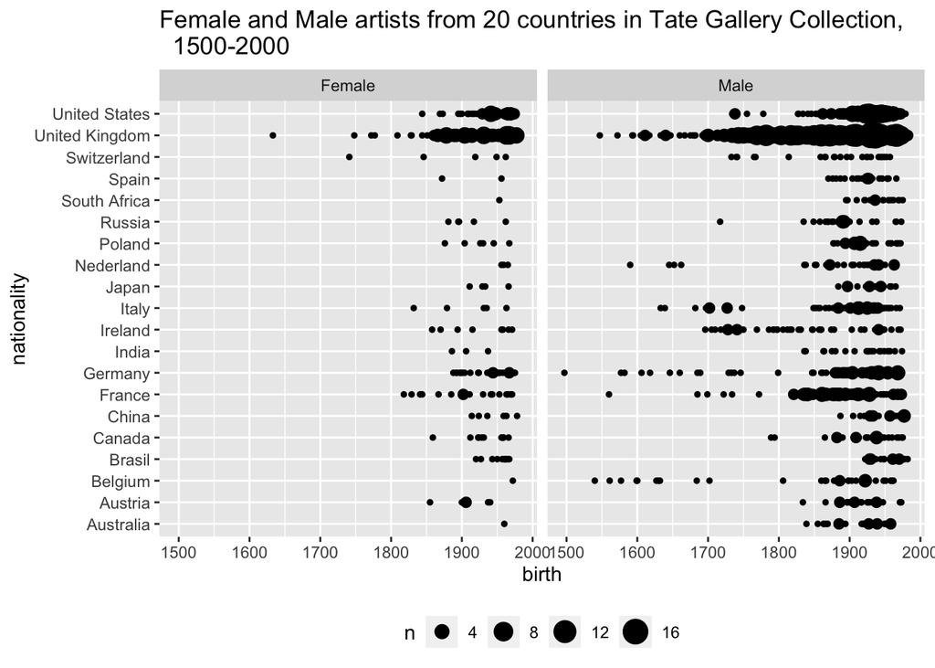

```r
top20nationality1 <- na.omit(top20nationality1)

top20nationality1%>%
  ggplot(mapping = aes(birth, nationality))+
  geom_point(size=0.5)+
  geom_count()+
  facet_wrap(~gender, ncol = 10)+
  theme(legend.position = "bottom")+
  labs(title = "Female and Male artists from 20 countries in Tate Gallery Collection,
  1500-2000")
```

```r
top20nationality1
```

```
## # A tibble: 2,693 × 5
##       id name                   gender birth nationality
##    <dbl> <chr>                  <chr>  <dbl> <chr>
##  1 10093 Abakanowicz, Magdalena Female  1930 Poland
##  2     0 Abbey, Edwin Austin    Male    1852 United States
##  3  2756 Abbott, Berenice       Female  1898 United States
##  4     1 Abbott, Lemuel Francis Male    1760 United Kingdom
##  5   622 Abrahams, Ivor         Male    1935 United Kingdom
##  6  9550 Abts, Tomma            Female  1967 Germany
##  7   623 Acconci, Vito          Male    1940 United States
##  8   624 Ackling, Roger         Male    1947 United Kingdom
##  9   625 Ackroyd, Norman        Male    1938 United Kingdom
## 10  2411 Adam, Robert           Male    1728 United Kingdom
## # … with 2,683 more rows
```

This plot shows birth year on the x-axis, top20nationality on the y-axis, the two columns represent gender and “n” is the size of how many artists from a top20nation is represented in the data set.

The project wished to compare gender and nationality in one visualization. However, the workflow to do so was complicated. By using a negator to filter out every country not on the top20nationality, the plot was created. It was not possible to filter out the top20nationality.

# Working with artwork_clean.csv

## Counting acquisition

```r
artwork %>%
  count(acquisition, sort = TRUE)
```

```
## # A tibble: 11 × 2
##    acquisition                       n
##    <chr>                         <int>
##  1 Accepted                      38279
##  2 Presented                     14815
##  3 Purchased                     12620
##  4 Bequeathed                     1275
##  5 Acquired through donation      1141
##  6 Transferred                    1049
##  7 Acquired by purchase and gift    15
##  8 <NA>                              3
##  9 Uncovered during remounting       2
## 10 Commissioned                      1
## 11 Exchanged                         1
```

### Using ggplot to create a plot showing acquisition

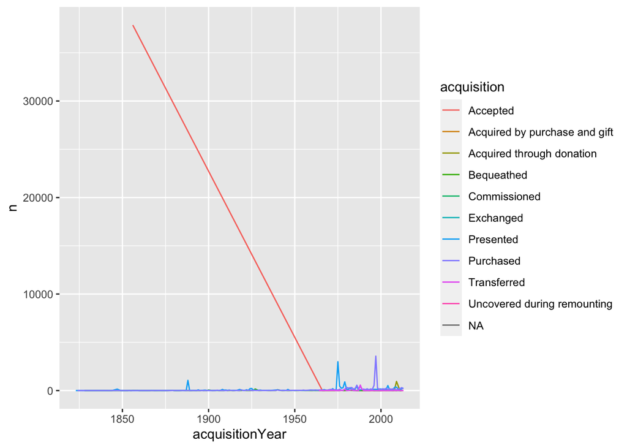

```r
artwork %>%
  count(acquisitionYear, acquisition) %>%
  ggplot(aes(x=acquisitionYear, y=n, colour=acquisition))+
  geom_line()
```

By counting acquisition in line 172-175 it is evident, that “Accepted” is the most common method of obtaining artwork. Looking at the data set “artwork_clean.csv, all accepted pieces of artwork, except a few, were part of the J.M.W Turner bequest of 1856, the largest art donation ever. Therefore, the graph is disproportional. By removing”Accepted” from the code, a visualization of acquisition, without the Turner bequest, will be readable.To do so, the negator “!” was used.

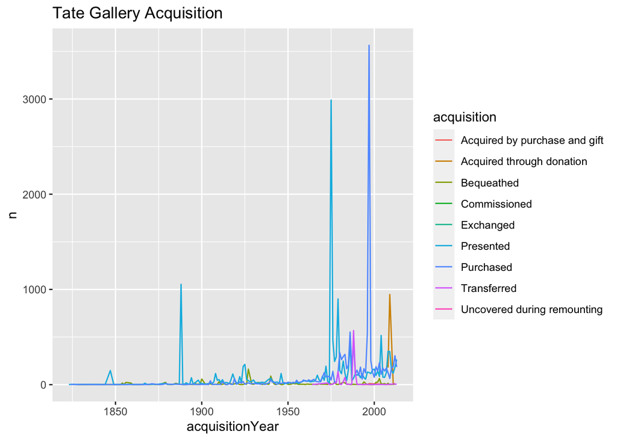

```r
artwork %>%
  filter(acquisition != "Accepted") %>%
  count(acquisitionYear, acquisition) %>%
  ggplot(aes(x=acquisitionYear, y=n, colour=acquisition))+
  geom_line()+
  labs(title = "Tate Gallery Acquisition")
```

Here, the prior graph is improved and shows the general trends. It shows the year of acquisition on the x-axis and the number of artwork on the y-axis. The color is acquisition method.

# Final comments

This code has briefly examined gender and nationality in the Tate Gallery Archive. The workflow was characterized by a curious approach, and by working inductively, graphs were improved and new opportunities came forth along the way.By counting the top 20 nationality in the artist_clean.csv file, I found fewer Indian born artists than I expected. A discovery worth reflecting upon historically and culturally. The artwork_clean.csv data set showed the general trends in acquisition. However, the interpretation behind the metadata is necessary to access whether to repatriate or not.